# COMPSCIX 415.2 Homework 5/Midterm

Aparna Vaidya

2/26/2019

My Github repository for my assignments can be found at this URL https://github.com/aparnav99/compscix-415-2-assignments.git

### The tidyverse packages (3 points)

```r
library(tidyverse)
```

By now you’ve used at least five different packages from the tidyverse for plotting, data munging, reshaping data, importing/exporting data, and using tibbles (the tibble package is used for this without you even realizing it’s there).

**1. Can you name which package is associated with each task below?**

- Plotting - ggplot2
- Data munging/wrangling - dplyr
- Reshaping (speading and gathering) data - tidyr
- Importing/exporting data - readr

**2. Now can you name two functions that you’ve used from each package that you listed above for these tasks?**

- Plotting - ggplot, geom_*** (e.g. geom_bar)
- Data munging/wrangling - select, filter
- Reshaping data - spread, gather
- Importing/exporting data - read.delim, write.csv

### R Basics (1.5 points)

**1. Fix this code with the fewest number of changes possible so it works:**

Code works by removing ‘!’ at the end of variable name.

```r
My_data.name___is.too00ooLong <- c( 1 , 2   , 3 )
```

**2. Fix this code so it works:**

Code works by changing ‘C’ to ‘c’ for vector and by adding a single quote to elclose ‘it’.

```r
my_string <- c('has', 'an', 'error', 'in', 'it')
```

**3. Look at the code below and comment on what happened to the values in the vector.**

All ‘int’ values in the vector got converted to ‘char’.

```r
my_vector <- c(1, 2, '3', '4', 5)
my_vector
```

```
## [1] "1" "2" "3" "4" "5"
```

### Data import/export (3 points)

**1. Download the rail_trail.txt file from Canvas (in the Midterm Exam section) and successfully import it into R. Prove that it was imported successfully by including your import code and taking a glimpse of the result.**

```r
rail_trail <- read.delim("rail_trail.txt", sep = "|")
glimpse(rail_trail)
```

```
## Observations: 90
## Variables: 10
## $ hightemp   <int> 83, 73, 74, 95, 44, 69, 66, 66, 80, 79, 78, 65, 41, 5…
## $ lowtemp    <int> 50, 49, 52, 61, 52, 54, 39, 38, 55, 45, 55, 48, 49, 3…
## $ avgtemp    <dbl> 66.5, 61.0, 63.0, 78.0, 48.0, 61.5, 52.5, 52.0, 67.5,…
## $ spring     <int> 0, 0, 1, 0, 1, 1, 1, 1, 0, 0, 0, 1, 1, 0, 0, 1, 0, 1,…
## $ summer     <int> 1, 1, 0, 1, 0, 0, 0, 0, 1, 1, 1, 0, 0, 0, 0, 0, 1, 0,…
## $ fall       <int> 0, 0, 0, 0, 0, 0, 0, 0, 0, 0, 0, 0, 0, 1, 1, 0, 0, 0,…
## $ cloudcover <dbl> 7.6, 6.3, 7.5, 2.6, 10.0, 6.6, 2.4, 0.0, 3.8, 4.1, 8.…
## $ precip     <dbl> 0.00, 0.29, 0.32, 0.00, 0.14, 0.02, 0.00, 0.00, 0.00,…
## $ volume     <int> 501, 419, 397, 385, 200, 375, 417, 629, 533, 547, 432…
## $ weekday    <int> 1, 1, 1, 0, 1, 1, 1, 0, 0, 1, 1, 1, 1, 1, 1, 1, 0, 1,…
```

**2. Export the file into a comma-separated file and name it “rail_trail.csv”. Make sure you define the path correctly so that you know where it gets saved. Then reload the file. Include your export and import code and take another glimpse.**

```r
write.csv(rail_trail, "rail_trail.csv")

rail_trail_csv = read.csv("rail_trail.csv")

glimpse(rail_trail_csv)
```

```
## Observations: 90
## Variables: 11
## $ X          <int> 1, 2, 3, 4, 5, 6, 7, 8, 9, 10, 11, 12, 13, 14, 15, 16…
## $ hightemp   <int> 83, 73, 74, 95, 44, 69, 66, 66, 80, 79, 78, 65, 41, 5…
## $ lowtemp    <int> 50, 49, 52, 61, 52, 54, 39, 38, 55, 45, 55, 48, 49, 3…
## $ avgtemp    <dbl> 66.5, 61.0, 63.0, 78.0, 48.0, 61.5, 52.5, 52.0, 67.5,…
## $ spring     <int> 0, 0, 1, 0, 1, 1, 1, 1, 0, 0, 0, 1, 1, 0, 0, 1, 0, 1,…
## $ summer     <int> 1, 1, 0, 1, 0, 0, 0, 0, 1, 1, 1, 0, 0, 0, 0, 0, 1, 0,…
## $ fall       <int> 0, 0, 0, 0, 0, 0, 0, 0, 0, 0, 0, 0, 0, 1, 1, 0, 0, 0,…
## $ cloudcover <dbl> 7.6, 6.3, 7.5, 2.6, 10.0, 6.6, 2.4, 0.0, 3.8, 4.1, 8.…
## $ precip     <dbl> 0.00, 0.29, 0.32, 0.00, 0.14, 0.02, 0.00, 0.00, 0.00,…
## $ volume     <int> 501, 419, 397, 385, 200, 375, 417, 629, 533, 547, 432…
## $ weekday    <int> 1, 1, 1, 0, 1, 1, 1, 0, 0, 1, 1, 1, 1, 1, 1, 1, 0, 1,…
```

### Visualization (6 points)

**1. Critique this graphic: give only three examples of what is wrong with this graphic. Be concise.**

- This graph mixes age group and gender categories in one scale.
- Addition of percentage between ‘yes/no’, age or gender categories do not add up to be 100%.
- Choice of visualization/color scheme not very intuitive.

**2. Reproduce this graphic using the diamonds data set.**

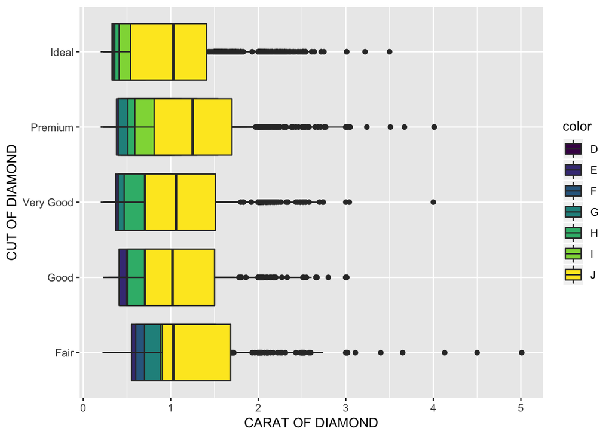

```r
ggplot(data = diamonds, mapping = aes(x = cut, y = carat, fill = color)) + geom_boxplot(position = "identity") + coord_flip() + labs(x = "CUT OF DIAMOND", y = "CARAT OF DIAMOND")
```

**3. The previous graphic is not very useful. We can make it much more useful by changing one thing about it. Make the change and plot it again.**

Change the position to ‘dodge2’ so the bars are not plotted on top of each other.

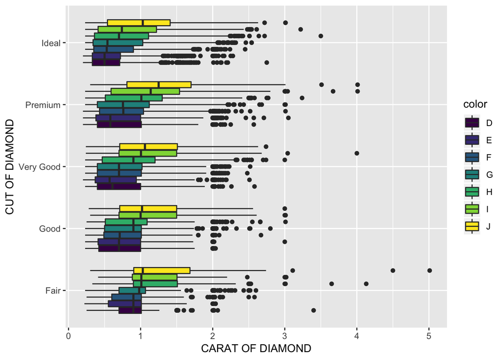

```r
ggplot(data = diamonds, mapping = aes(x = cut, y = carat, fill = color)) + geom_boxplot(position = "dodge2") + coord_flip() + labs(x = "CUT OF DIAMOND", y = "CARAT OF DIAMOND")
```

### Data munging and wrangling (6 points)

**1.Is this data “tidy”? If yes, leave it alone and go to the next problem. If no, make it tidy. Note: this data set is called table2 and is available in the tidyverse package. It should be ready for you to use after you’ve loaded the tidyverse package.**

Yes. This data is tidy because of following reasons -

- Each column is a variable
- Each row is an observation
- Each cell is a value

**2. Create a new column in the diamonds data set called price_per_carat that shows the price of each diamond per carat (hint: divide). Only show me the code, not the output.**

```r
mutate(diamonds, price_per_carat = price/carat)
```

**3. For each cut of diamond in the diamonds data set, how many diamonds, and what proportion, have a price > 10000 and a carat < 1.5? There are several ways to get to an answer, but your solution must use the data wrangling verbs from the tidyverse in order to get credit.**

```r
diamonds %>% group_by(cut) %>%
         filter(price > 10000, carat < 1.5) %>%
         summarise(count = n()) %>%
         mutate(proportion = prop.table(count))
```

```
## # A tibble: 5 x 3
##   cut       count proportion
##   <ord>     <int>      <dbl>
## 1 Fair          4    0.00480
## 2 Good         17    0.0204
## 3 Very Good   155    0.186
## 4 Premium     173    0.207
## 5 Ideal       485    0.582
```

- **Do the results make sense? Why?**

The results make sense since there are higher proprtion of diamonds from premium and ideal category since those tend to be high price diamonds.

- **Do we need to be wary of any of these numbers? Why?**

Higher weight may not always mean better quality so we need to be careful not to pay higher price only based on weight without considering the quality.

### EDA (6 points)

**Take a look at the txhousing data set that is included with the ggplot2 package and answer these questions:**

```r
glimpse(txhousing)
```

```
## Observations: 8,602
## Variables: 9
## $ city      <chr> "Abilene", "Abilene", "Abilene", "Abilene", "Abilene",…
## $ year      <int> 2000, 2000, 2000, 2000, 2000, 2000, 2000, 2000, 2000, …
## $ month     <int> 1, 2, 3, 4, 5, 6, 7, 8, 9, 10, 11, 12, 1, 2, 3, 4, 5, …
## $ sales     <dbl> 72, 98, 130, 98, 141, 156, 152, 131, 104, 101, 100, 92…
## $ volume    <dbl> 5380000, 6505000, 9285000, 9730000, 10590000, 13910000…
## $ median    <dbl> 71400, 58700, 58100, 68600, 67300, 66900, 73500, 75000…
## $ listings  <dbl> 701, 746, 784, 785, 794, 780, 742, 765, 771, 764, 721,…
## $ inventory <dbl> 6.3, 6.6, 6.8, 6.9, 6.8, 6.6, 6.2, 6.4, 6.5, 6.6, 6.2,…
## $ date      <dbl> 2000.000, 2000.083, 2000.167, 2000.250, 2000.333, 2000…
```

**1. During what time period is this data from?**

This data is from 2000-2015 timeframe.

```r
distinct(txhousing, year)
```

```
## # A tibble: 16 x 1
##     year
##    <int>
##  1  2000
##  2  2001
##  3  2002
##  4  2003
##  5  2004
##  6  2005
##  7  2006
##  8  2007
##  9  2008
## 10  2009
## 11  2010
## 12  2011
## 13  2012
## 14  2013
## 15  2014
## 16  2015
```

**2. How many cities are represented?**

46 cities are represented

```r
count(distinct(txhousing, city, na.rm = TRUE))
```

```
## # A tibble: 1 x 1
##       n
##   <int>
## 1    46
```

**3. Which city, month and year had the highest number of sales?**

- Houston had highest number of sales in July of 2015.
- City with highest number of sales of all times is Houston.
- Month with highest number of sales of all times is July 2015.
- Year with highest number of sales of all times is 2006

```r
txhousing %>% group_by(city, month, year) %>% summarise(sales = sum(sales)) %>% arrange(desc(sales))
```

```
## # A tibble: 8,602 x 4
## # Groups:   city, month [552]
##    city    month  year sales
##    <chr>   <int> <int> <dbl>
##  1 Houston     7  2015  8945
##  2 Houston     6  2006  8628
##  3 Houston     7  2013  8468
##  4 Houston     6  2015  8449
##  5 Houston     5  2013  8439
##  6 Houston     6  2014  8391
##  7 Houston     7  2014  8391
##  8 Houston     8  2014  8167
##  9 Houston     8  2013  8155
## 10 Houston     5  2006  8040
## # … with 8,592 more rows
```

```r
txhousing %>% group_by(city) %>% summarise(sales = sum(sales, na.rm = TRUE)) %>% arrange(desc(sales))
```

```
## # A tibble: 46 x 2
##    city                sales
##    <chr>               <dbl>
##  1 Houston           1043999
##  2 Dallas             816122
##  3 Austin             373381
##  4 San Antonio        322097
##  5 Collin County      202892
##  6 Fort Bend          153088
##  7 Fort Worth         144791
##  8 NE Tarrant County  128007
##  9 Denton County      117405
## 10 Montgomery County  104589
## # … with 36 more rows
```

```r
txhousing %>% group_by(year, month) %>% summarise(sales = sum(sales, na.rm = TRUE)) %>% arrange(desc(sales))
```

```
## # A tibble: 187 x 3
## # Groups:   year [16]
##     year month sales
##    <int> <int> <dbl>
##  1  2015     7 37651
##  2  2006     6 37570
##  3  2015     6 37099
##  4  2014     6 35766
##  5  2013     7 35412
##  6  2014     7 35277
##  7  2013     5 34866
##  8  2006     8 34701
##  9  2013     8 34566
## 10  2006     5 34340
## # … with 177 more rows
```

```r
txhousing %>% group_by(year) %>% summarise(sales = sum(sales, na.rm = TRUE)) %>% arrange(desc(sales))
```

```
## # A tibble: 16 x 2
##     year  sales
##    <int>  <dbl>
##  1  2006 347733
##  2  2014 345720
##  3  2013 335094
##  4  2007 327701
##  5  2005 316046
##  6  2012 287052
##  7  2004 283999
##  8  2008 276664
##  9  2009 255254
## 10  2003 253909
## 11  2011 246356
## 12  2010 243014
## 13  2002 234600
## 14  2001 231453
## 15  2000 222483
## 16  2015 208124
```

**4. What kind of relationship do you think exists between the number of listings and the number of sales? Check your assumption and show your work.**

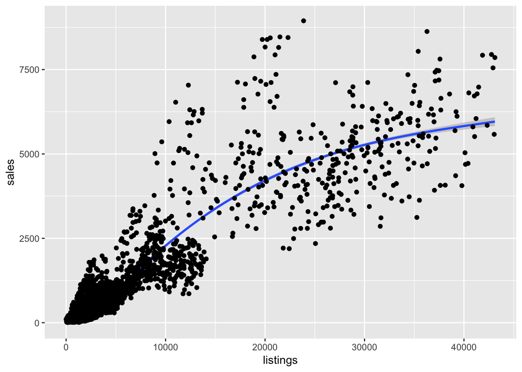

```r
ggplot(data = txhousing, mapping = aes(x = listings, y = sales)) +
  geom_point() + geom_smooth() + geom_jitter()
```

**5. What proportion of sales is missing for each city?**

20 out of 46 cities have some missing sales. Proportion varies from 0.1% to 20%

```r
txhousing %>% group_by(city) %>%
         filter(is.na(sales)) %>%
         summarise(count = n()) %>%
         mutate(proportion = prop.table(count))  %>%
         arrange(desc(proportion))
```

```
## # A tibble: 20 x 3
##    city               count proportion
##    <chr>              <int>      <dbl>
##  1 South Padre Island   116    0.204
##  2 Kerrville            104    0.183
##  3 Midland               75    0.132
##  4 Odessa                72    0.127
##  5 San Marcos            46    0.0810
##  6 Laredo                36    0.0634
##  7 Harlingen             25    0.0440
##  8 Waco                  19    0.0335
##  9 Texarkana             17    0.0299
## 10 Brazoria County       14    0.0246
## 11 Longview-Marshall     12    0.0211
## 12 Nacogdoches           11    0.0194
## 13 Temple-Belton         11    0.0194
## 14 Brownsville            2    0.00352
## 15 McAllen                2    0.00352
## 16 Port Arthur            2    0.00352
## 17 Corpus Christi         1    0.00176
## 18 Galveston              1    0.00176
## 19 Killeen-Fort Hood      1    0.00176
## 20 Lubbock                1    0.00176
```

**6. Looking at only the cities and months with greater than 500 sales:**

```r
txhousing %>% group_by(city, month) %>%
         filter(sales > 500)
```

```
## # A tibble: 1,883 x 9
## # Groups:   city, month [153]
##    city       year month sales   volume median listings inventory  date
##    <chr>     <int> <int> <dbl>    <dbl>  <dbl>    <dbl>     <dbl> <dbl>
##  1 Arlington  2000     8   507 60875199 103400     1417       3.5 2001.
##  2 Arlington  2001     5   536 69878959 114400     1592       3.7 2001.
##  3 Arlington  2001     6   534 67744182 108500     1627       3.8 2001.
##  4 Arlington  2001     8   505 65080743 113600     1616       3.7 2002.
##  5 Arlington  2002     5   503 67240236 116100     1741       3.9 2002.
##  6 Arlington  2002     7   509 66954143 119100     1925       4.4 2002.
##  7 Arlington  2003     5   502 67131982 118000     2544       5.9 2003.
##  8 Arlington  2003     7   524 73194692 123500     2799       6.5 2004.
##  9 Arlington  2003     8   531 72397143 123900     2801       6.4 2004.
## 10 Arlington  2004     5   527 72401436 118300     2922       6.5 2004.
## # … with 1,873 more rows
```

- **Are the distributions of the median sales price (column name median), when grouped by city, different? The same? Show your work.**

The distributions of median sales price are about the same in both cases.

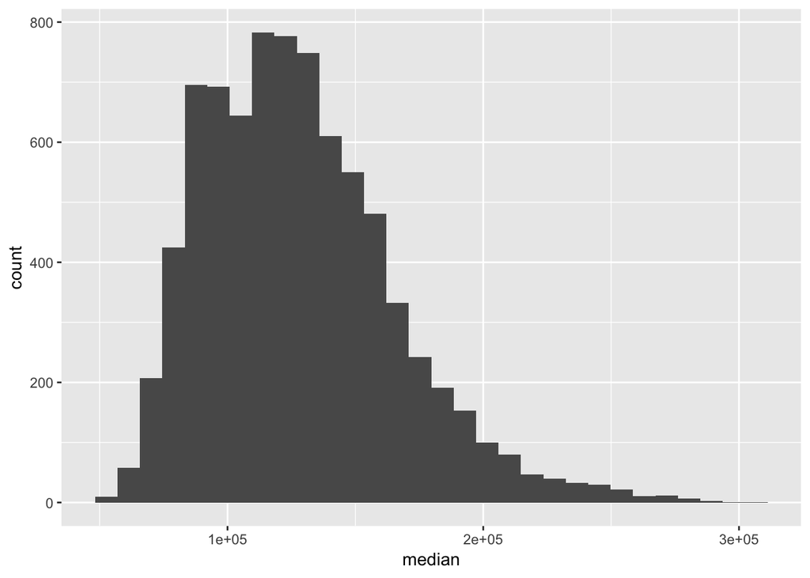

```r
ggplot(data = txhousing, mapping = aes(x = median)) + geom_histogram()
```

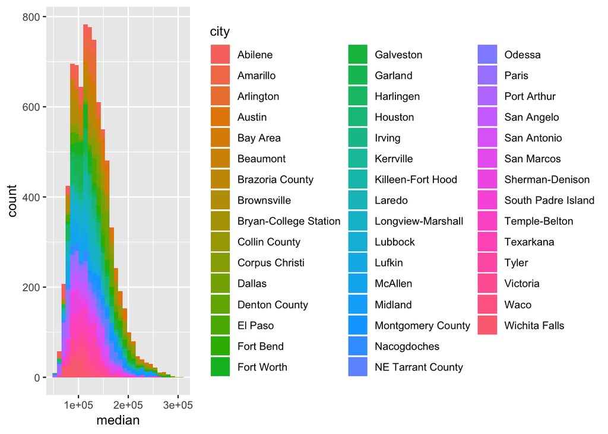

```r
ggplot(data = txhousing, mapping = aes(x = median, fill = city)) + geom_histogram()
```

- **Any cities that stand out that you’d want to investigate further?**

Would like to look at different cities in Texas (Austin, Dallas, San Antonio) to see what might be causing such a big difference in the sales in the same state. Would also like to look at Bay Area to check why there is a steep slope from median to the tail end.

- **Why might we want to filter out all cities and months with sales less than 500?**

This will help reduce the noise and help concentrate the analysis on important sales. Cities less than 500 sales are not adding any significant value to the revenue.

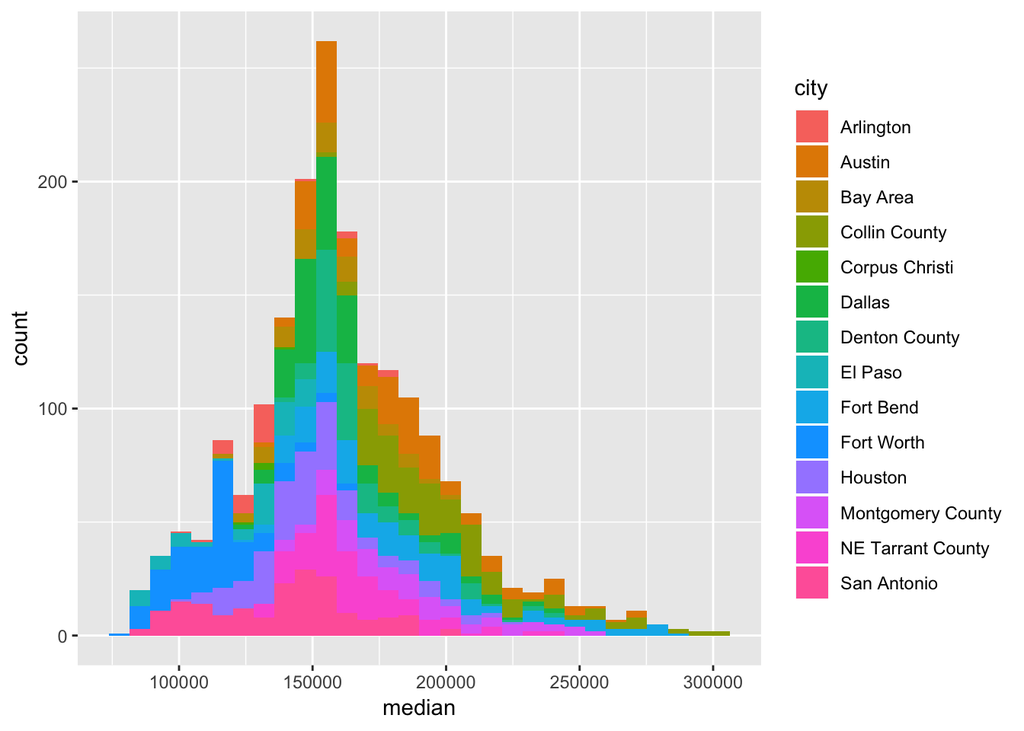

```r
txhousing %>% filter(sales > 500) %>%
ggplot(mapping = aes(x = median, fill = city)) + geom_histogram()
```